# Pool Size Matters: Backtesting March Madness Strategies

March 7, 2018

I made an [app](https://bracketmath.shinyapps.io/ncaa/) to optimize March Madness brackets. You can read more about it [here](https://github.com/dlm1223/march-madness/blob/master/README.md). For this post, I’m going to use the app to look at what size pool you should enter and also what parameters you should use in the app.

## Testing Parameter Combos:

I’m using 500 simulations-500 brackets for this and am testing it over 8 seasons, 2010-2017. I use the simulations and brackets to choose the optimal brackets and then I look at the profit and ROI using the actual results for the given year. **The first thing I do is look at performance of different parameter combos of the app.**

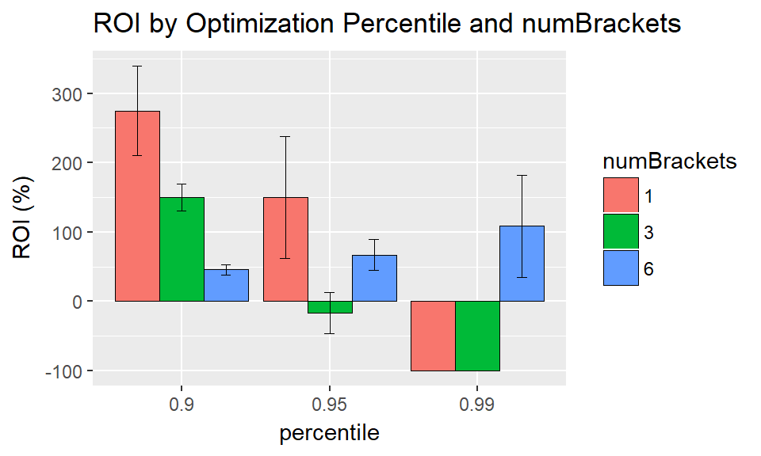

To get ROI above, I assume you entered $1/bracket and first place gets everything. So, for example percentile-99 means you are using .99 as the parameter and that the payout is $100 if the actual percentile was >=.99. So if I entered 1 bracket each year and won 20 dollars, my ROI=(20-8)/8*100=150%. Below I look more closely at the .90-parameter backtest:

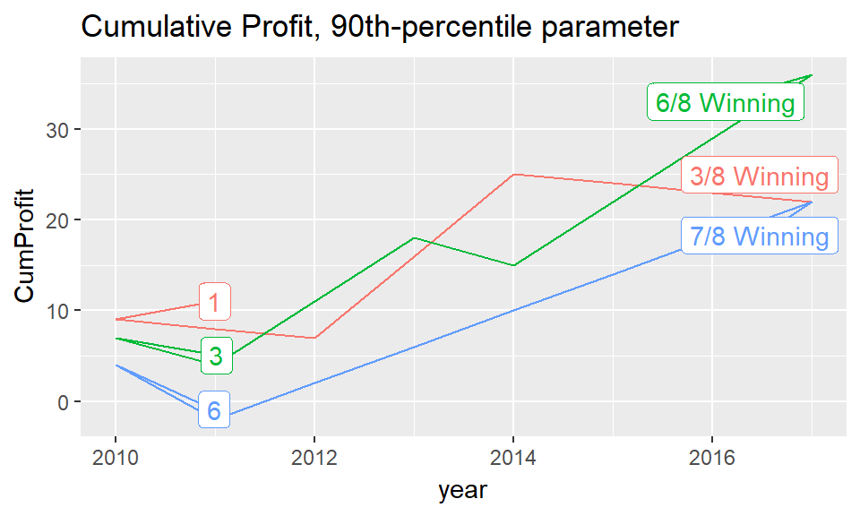

As you can see in the above plots, the brackets from the 90th-percentile-parameter do best, and diversifying even has you winning in 7/8 years.

## Testing Payout Structures:

**My next question is: is the better ROI for the 90th-percentile-parameter a function of the optimization algorithm or a function of the payout structure?** Meaning, is it doing better because it is giving you better brackets or because the payout structure is less top heavy? To test this hypothesis I use the same algorithm output but I re-calculate ROI using a medium-pool 20-man payout. Below I repeat the same pots, but calculate all payouts using the medium 20-man pool scoring as the scoring for all the parameters:

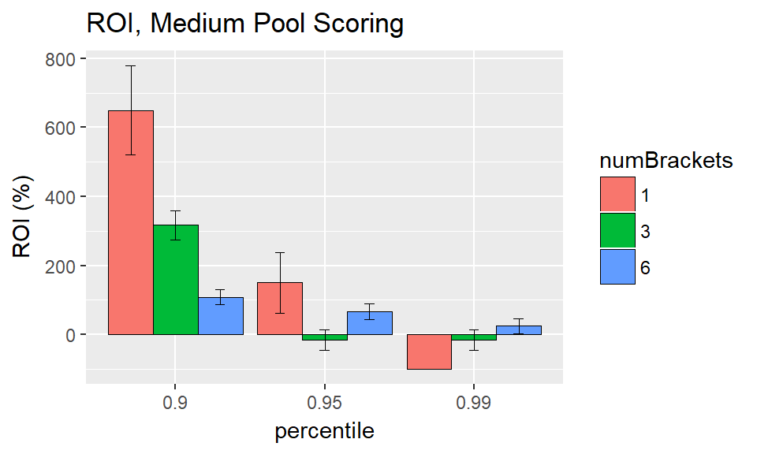

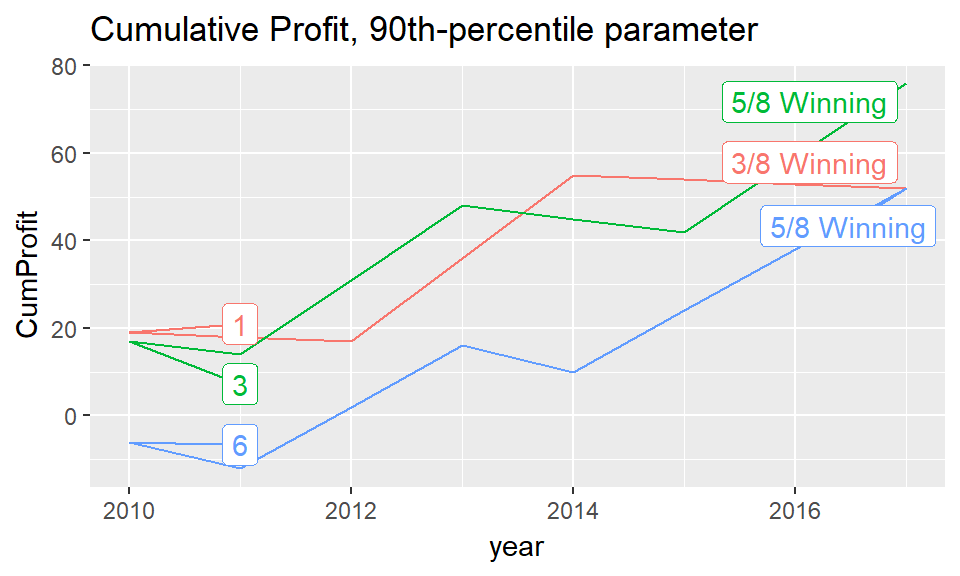

As you can see, optimization on 90th percentile still gave the best result, even in a larger pool. But while the ROI is higher, the percentage of winning years starts to decrease. I repeat this again using 100-man pool scoring:

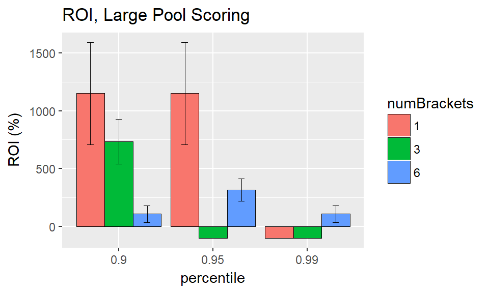

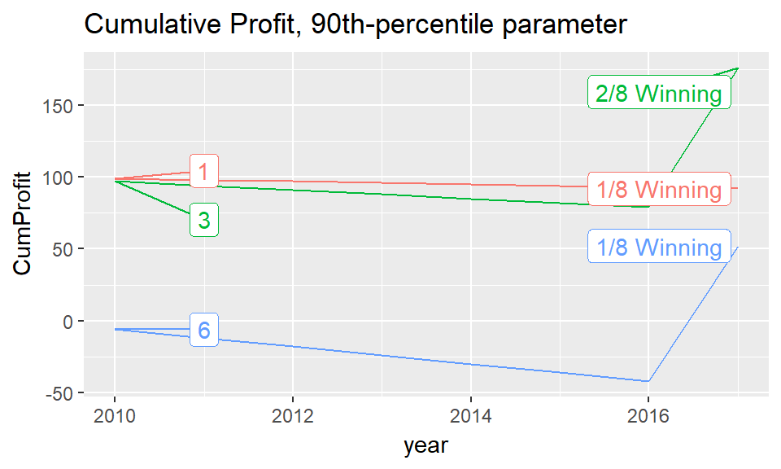

90th percentile always does well. I’m not sure the reason for this but I’m guessing it has to do with sample size and that using 90% gives you brackets that have variance but are not overfit to your simulations. It could also just be that I am overfitting to the backtest, so doing things like testing sensitivity to different projection systems is something that would be worthwhile.

## Conclusion:

Overall, a system should give you good results and also have good median results. In finance, they have things like Sharpe ratio to measure the trade-off of risk and returns. However, just by looking at the plots, it seems the best thing to do is to **use .9 optimization percentile and to multi-enter. This is true regardless of your actual pool size. If you have a choice,it’s best to enter small pools (<=20 people)**. With pools of this size you are giving yourself a really good shot of winning.Ideally, you have a lot of friends and can divide them into different groups without them knowing. That way you can put a different bracket in each group. Or, make a pool that allows for multi-entry. While the largest pools may give the most profit over time, it’s better to enter smaller pools to reduce your risk of losing. All of this has been for 1-2-4-8-16-32 scoring. I also assume brackets cannot finish in the same place i.e. you are multi-entering the same pool. Because the optimized brackets are so uncorrelated this assumption doesn’t really matter. In a future post I will examine different scoring systems in addition to testing sensitivity of this analysis to a different projections system. You can replicate my analysis by manually running the [app](https://bracketmath.shinyapps.io/ncaa/) or by downloading my code from [github](https://github.com/dlm1223/march-madness/tree/master/Backtest%20files).